# Impact uncertainty vG parameters on recharge

G. Bier

October 2023

# Introduction

Markdown to set up an unsaturated zone model and to analyze the impact of the van Genuchten parameters on Evapotranspiration, moisture distribution and groundwater recharge.

### Cleaning the memory and loading required package(s)

```
rm(list = ls())
library(FVFE1D)
library(MIPLOT)
```

# van Genuchten Functions

For the simulation of flow in the unsaturated zone, the $k(\psi)$ is required and $\theta(\psi)$ relation will be used to determine the moisture content in the profile.

The relations between moisture content and pressure and hydraulic conductivity and pressure are:

$$\theta(\psi) = \theta_r +\frac{\theta_s -
\theta_r}{[1+(|\alpha\psi|)^n]^{m}}\\
S = [\left ( 1+|\alpha \psi|\right )^n]^{-m} \\
k(\psi) = k_{sat} S^{\lambda}(1-(1-S^{1/m})^m)^2$$

```
pF.pnt = seq(4.2,-5,length.out = 300) #generate 300 points in the pF (-log(psi)) range of 0 and 4.2
psi = -10^pF.pnt

generate.vG.curves = function(type = string,n,alpha,theta.sat,theta.res,ksat,lambda)
{
  m = 1-1/n    ##m is just a helper parameter
  S = (1+abs(alpha*psi)^n)^(-m) ## S is also some intermediate result
  theta.un.table = theta.res+(theta.sat-theta.res)*S ##here a table is setup for the theta(psi)-relation
  K.un.table = ksat*S^lambda*(1-(1-S^(1/m))^m)^2 ##here the table holds the K(theta) data
  K.un.table[K.un.table < 1e-5] = 1e-5
  C.un.table = (theta.sat-theta.res)*m*n*alpha*abs(alpha*psi)^(n-1)*
    (1+abs(alpha*psi)^n)^(-m-1)
  #below functions are created from the calculated data points
  k.fun <<- approxfun(psi,K.un.table,rule=2)
  theta.fun <<- approxfun(psi,theta.un.table,rule=2)
  c.fun <<- approxfun(psi,C.un.table,rule=2)

}

#just a view vG values for some soils.
##########################VAN GENUCHTEN CURVES##############################################
# soil type|theta.res|theta.sat|n     |alpha  |Ksat |lambda |soil name
#------------------------------------------------------------------------
# B1       |0.02     |0.43     |1.801 |0.0234 |23.41|-0.000 |fine/moderate fine sand
# B5       |0.01     |0.36     |1.933 |0.0452 |52.91|-0.359 |coarse sand
# B8       |0.01     |0.43     |1.288 |0.0099 |2.36 |-2.244 |loamy sand
# B12      |0.01     |0.54     |1.094 |0.0239 |5.37 |-5.681 |heavy clay

generate.vG.curves("B01",1.801,0.0234,0.43,0.02,23.41,-0.000)#data of B1


#two plot function for inspecting the k(psi) and theta(psi) relations of the current soil
plot.kfun = function(soiltype = string)
{
  plot(k.fun(psi),pF.pnt, type = "l", lwd = 2, col = "blue",
       main = paste("Hydraulic conductivity as function of pF of",soiltype),
       xlab = "k(psi), (cm/d)", ylab = "|log(psi)|")
  grid()
}

plot.thetafun = function(soiltype = string)
{
  plot(theta.fun(psi),pF.pnt, type="l", lwd = 2, col = "red",
       main = paste("Moisture content as function of psi (-) of",as.character(soiltype)) ,
       xlab = "moisture content (fraction)",
       ylab = "|log(psi)|")
  grid()
}

plot.kfun("B01")
```

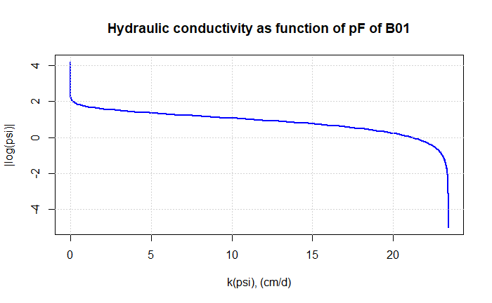

```
plot.thetafun("B01")
```

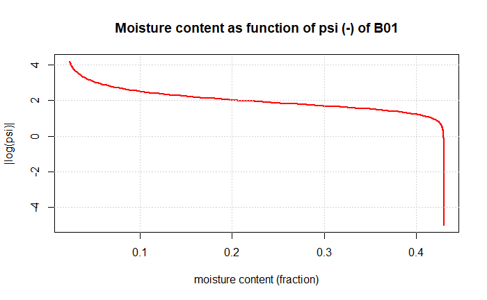

## Intermezzo….

### Data OK?

Ik zag in O15 een max k.sat staan van 178.593 maar die komt niet terug in de grafiek!

Dus maar even vergelijken met de data uit het rapport(water retentie karakteristieken…..2018). Hmmm

Dat is op log(k.sat)-log(psi) schaal gedaan, dus hier ook maar even.

```
plot.logkfun = function(soiltype = string)
{
  log.kfun = log10(k.fun(psi))
  log.pFpnt = log10(pF.pnt)
  plot(log.pFpnt, type = "l", lwd = 2, col = "blue",
       main = paste("Hydraulic conductivity as function of pF of",soiltype),
       xlab = "k(psi), (cm/d)", ylab = "|log(psi)|")
  grid()
}
```

# Model setup

## Internal flux in the unsaturated zone

The equation describing the internal flux in the unsaturated zone strongly resembles the basic Darcy equation to simulate flow in the saturated zone. Most important differences are the hydraulic conductivity and the state. Now the state is $\psi$ instead of $H$. Both are related: $H = \psi + z$ where the $z$ is the datum/reference (in the Netherlands: “NAP”).

$$q=-k(\psi)\left [\frac{\partial \psi}{\partial z} + 1 \right]$$

## Building the model

**Be aware** the length unit is in cm!

The model is based on:

- 1D vertical flow
- Richards/Darcy’s equation
- Top boundary flux based precipitation
- Bottom boundary flux based on Dirichlet or Cauchy type
- Spatial flux for the rooting function for transpiration
- Soil evaporation is neglected

```
#for soil O01
soiltype = "O01"
n = 2.163
alpha = 0.016
theta.sat = 0.366
theta.res = 0.01
ksat = 22.32
lambda = 2.868
generate.vG.curves(soiltype,n,alpha,theta.sat,theta.res,ksat,lambda)


## domain of the model
top = 0.0  # at the surface
bottom = -2000#-200 # so 200 cm below surface!!

domain=c(bottom,top)


###description of the internal flux##############
unsatdarcy.flux = function(z,psi,dpsidz)
{
  return(-k.fun(psi)*(dpsidz+1))
}

################### make the model #################
UnsatStat = newFLOW1D(domain,unsatdarcy.flux,"Unsaturated zone, 1D stationary")

####### discretisation #####################
# position the nodes 2 cm apart
nodes = seq(from=domain[1],to=domain[2],by=2)
set.discretisation(UnsatStat,nodes,"FE") #setting to FEquartic slows transient simulations way too much
# An initialisation is certainly important (as the default initialisation by zeros does not make sense here).
# So we initialize with a no-flux profile:
Psi.equi = approxfun(c(domain[1],domain[2]),c(domain[2],domain[1]))
do.initialize(UnsatStat,Psi.equi)

# We want to avoid pressures to be too negative (<-1E-5)
Psi.in.range = function(z,Psi) # it has 2 arguments; the position and the state. Set the min. value to pF4.2 not pF5
{
  # if(Psi<=-1*10^4.2) return(FALSE)
   if(Psi<=-1*10^5) return(FALSE)
  else return(TRUE)
}
set.isacceptable(UnsatStat,Psi.in.range) #the set.isacceptable function limits the possible values that the state can become

############## Boundary conditions ##################
set.BC.fixedstate(UnsatStat,"left",0.0)
# At the bottom of the model, where the groundwater level is located, both pressure head and elevation head are zero.

ppt = 0.1
set.BC.fixedflux(UnsatStat,"right","ppt")
# 0.1cm/d=1mm/d. Although this flow is directed downwards, we define it positive because it goes into the domain.


######## checking and solving the model ####################
summary(UnsatStat)
```

```
one dimensional flow model
name:  Unsaturated zone, 1D stationary
model has no spatial fluxes
model has no point fluxes
left BC is of type state
right BC is of type given flux

numerical model of type FElinear1D
number of nodes is  1001
```

```
solve.steps(UnsatStat,verboselevel=1)
```

```
[1] "iteration 1 ; RMSM= 0.0031620846502229 ; MAM= 0.0999938964843596"
[1] "iteration 2 ; RMSM= 0.00316203640084294 ; MAM= 0.0999923706985818"
[1] "iteration 3 ; RMSM= 0.00316198815238475 ; MAM= 0.0999908449360856"
[1] "iteration 4 ; RMSM= 0.00315909139173952 ; MAM= 0.0998992412120608"
[1] "iteration 5 ; RMSM= 0.00315889959703979 ; MAM= 0.0998931440910633"
[1] "iteration 6 ; RMSM= 0.00315753587115788 ; MAM= 0.0998499414356711"
[1] "iteration 7 ; RMSM= 0.00315297454343495 ; MAM= 0.0997000357835476"
[1] "iteration 8 ; RMSM= 0.00310203554118496 ; MAM= 0.0979436068164476"
[1] "iteration 9 ; RMSM= 0.00303638193160871 ; MAM= 0.0948153736108757"
[1] "iteration 10 ; RMSM= 0.00271179768824595 ; MAM= 0.0797062961234868"
[1] "iteration 11 ; RMSM= 0.00252775302540747 ; MAM= 0.0737145294339947"
[1] "iteration 12 ; RMSM= 0.00238091012497315 ; MAM= 0.0691225948012718"
[1] "iteration 13 ; RMSM= 0.0015241837228997 ; MAM= 0.0448991261332565"
[1] "iteration 14 ; RMSM= 0.00129006329425967 ; MAM= 0.0274425178862361"
[1] "iteration 15 ; RMSM= 0.00099568877564208 ; MAM= 0.0178089916872773"
[1] "iteration 16 ; RMSM= 0.000180570598254974 ; MAM= 0.00436891027118892"
[1] "stopped because of small RMSM= 0.00000181485779663234"
$RMSM
[1] 0.000001814858

$MAM
[1] 0.00005309031
```

```
plot(UnsatStat,fluxplot = T,vertical = T)
```

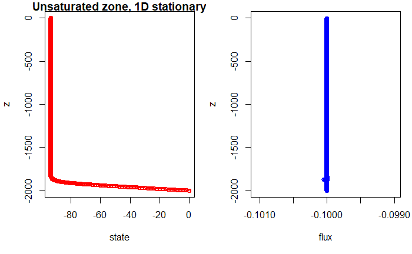

## Additional flow functions

In addition there will be functions for ponding, the lower boundary conditions (simulating the drainage effect) and transpiration of roots (Feddes function). The lower boundary condition is a Cauchy type BC:
$$Q_{drainge}= \frac{H_{drn.level} - H_{bottom}}{C}$$

```
drn.resistance = 100 #unit is in days
drn.level = -80 # so 80 cm below surface level
drn.fun = function(psi)
{
#  if((drn.level - (psi + bottom)) < 0) return((drn.level - (psi + bottom))/drn.resistance)
#  else return(0)
  return((drn.level - (psi + bottom))/drn.resistance)
}
```

### Replacing the bottom fixed head boundary condition with the drainage type

```
set.BC.fluxstate(UnsatStat,"left", drn.fun)
summary(UnsatStat)
```

```
one dimensional flow model
name:  Unsaturated zone, 1D stationary
model has no spatial fluxes
model has no point fluxes
left BC is of type state-flux
right BC is of type given flux

numerical model of type FElinear1D
number of nodes is  1001
```

```
drn.psi.equi = approxfun(c(domain[1],domain[2]),c((drn.level - bottom),drn.level))

do.initialize(UnsatStat,drn.psi.equi)
solve.steps(UnsatStat,verboselevel = 1)
```

```
[1] "iteration 1 ; RMSM= 0.00198912771902077 ; MAM= 0.0628744953899071"
[1] "iteration 2 ; RMSM= 0.00133427801556059 ; MAM= 0.041543807058431"
[1] "iteration 3 ; RMSM= 0.000978150008382029 ; MAM= 0.029052364714245"
[1] "iteration 4 ; RMSM= 0.000728243336842414 ; MAM= 0.02215985023281"
[1] "iteration 5 ; RMSM= 0.000556922074783713 ; MAM= 0.0165119798370463"
[1] "iteration 6 ; RMSM= 0.000521940160663162 ; MAM= 0.0057405916338687"
[1] "stopped because of small RMSM= 0.000000365847738335678"
$RMSM
[1] 0.0000003658477

$MAM
[1] 0.000007350626
```

```
plot(UnsatStat,fluxplot = T,vertical = T)
```

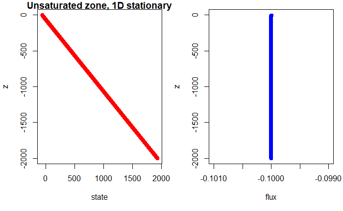

```
##trying the new bottom boundary condition with a view different ppt's
ppt = 0.2
solve.steps(UnsatStat,verboselevel = 1)
```

```
[1] "iteration 1 ; RMSM= 0.00251697114653726 ; MAM= 0.0774340137196775"
[1] "iteration 2 ; RMSM= 0.00196097846401215 ; MAM= 0.0601325183575864"
[1] "iteration 3 ; RMSM= 0.00173127999682073 ; MAM= 0.0223927249641936"
[1] "stopped because of small RMSM= 0.00000288251751693064"
$RMSM
[1] 0.000002882518

$MAM
[1] 0.00004352458
```

```
plot(UnsatStat,fluxplot = T,vertical = T)
```

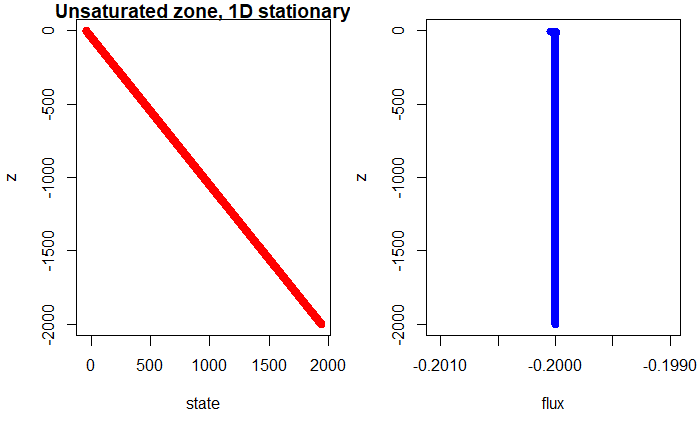

```
#ppt = -0.2
# solve.steps(UnsatStat,verboselevel = 1)
# plot(UnsatStat,fluxplot = T,vertical = T)
# dataframe.balance(UnsatStat)
# dataframe.boundaries(UnsatStat)

###plotting functions showing the water table in the profile,
### the moisture distribution and transpiration through the roots

plot.wtable = function(model)
{
  df = dataframe.states(model)
  plot(df$state, df$x, type = "o",col = "blue",lwd=2.5,
       main = "Psi(z), location water table", xlab = "psi in cm", ylab = "depth profile")
  abline(h = drn.level, col = "brown", lwd= 3, lty = "dashed")
  text(20,drn.level, "drainage level", col = "brown")
  psi.fun = approxfun(df$state,df$x)
  abline(h = psi.fun(0),col = "red", lwd = 2)
  text(20,psi.fun(0),"water table" , col = "red")
  grid()
}

plot.theta = function(model)
{
  df = dataframe.states(model)
  theta.psi = theta.fun(df$state)
  plot(theta.psi,df$x, type = "o", col = "green", lwd = 2.5,
       main = "Theta(z), moisture content in profile", xlab = "theta", ylab = "depth profile")
  abline(h = drn.level, col = "brown", lwd= 3, lty = "dashed")
  text((mean(theta.psi)),drn.level, "drainage level", col = "brown")
  grid()
}


plot.wtable(UnsatStat)
```

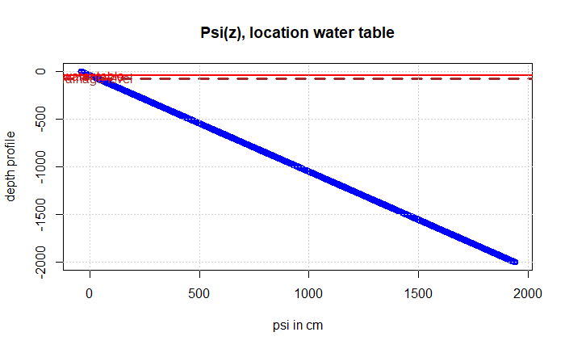

```
plot.theta(UnsatStat)
```

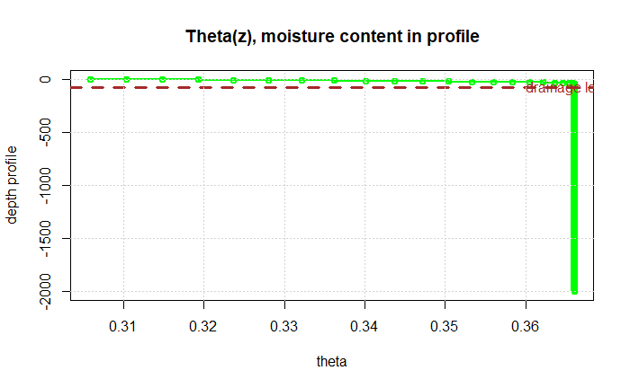

## Adding the vegetation to the model

Evapotranspiration is an important environmental condition for processes near the soil surface, such as the development of vegetation. Evapotranspiration depends on:

- The potential evapotranspiration rate, which is determined by weather conditions;
- The rooting distribution of the vegetation;
- The actual soil moisture contentin the rooting zone.

The total *potential* evapotranspiration rate of the vegetation is determined by weather conditions and will be given.

The rooting distribution may be described by a function `root.distr.fun(z)` which gives the fraction of roots present at each depth (giving 1 when integrated with depth). The rooting depth for each vegetation type can be described in many ways. Here, at this stage we will assume grass with 75% rooting in the first 20 cm and 25% till 110 cm below surface. (Just my guess).

```
root.partition = c(0.0,-20.0,-20.01,-110.0,-110.01)
root.rates.fractions = c(0.75/20,0.75/20,0.25/90,0.25/90,0.0)
root.distr.fun = approxfun(root.partition,root.rates.fractions,rule = 2)
plot(root.partition,root.distr.fun(root.partition), type = "o",
   col = "green", lwd = 2, main = "Root distribution function",
   ylab = "Fraction of the root distribution (-)", xlab = "Rooting depth (cm) rel. to surface level")
grid()
```

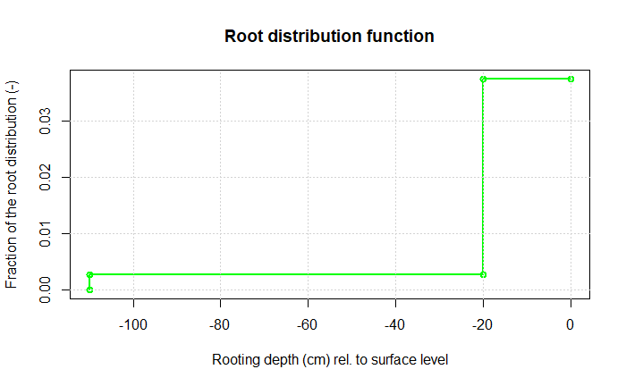

```
###check for the integral
20*0.75/20 + 90*0.25/90
```

```
[1] 1
```

```
z.root = seq(-109.5,-0.5,by = 1)
sum(root.distr.fun(z.root))
```

```
[1] 1
```

The vegetation can only transpire optimally when there is sufficient moisture in the soil which is ‘easily’ available for the vegetation. The effect of soil moisture can be simulated with the so called Feddes (retired Prof. from WUR) function.

The code chunk below illustrates such a Feddes function. This function relates the root water uptake at a certain depth with the pressure (suction) at that depth. When the soil is too wet or too dry, plant transpiration and thus root uptake are reduced below their potential rates, and the Feddes reduction factor is smaller than 1.

```
options(scipen = 999) #avoid scientific notation (with E power) in the plot
Feddes.psiabs = c(0.1,100,1000,16000) #typical psi values to define Feddes function. Note these are absolute psi's due to the plot. NOT in the function
Feddes.red = c(0,1,1,0)
Feddes.fun= approxfun(-Feddes.psiabs,Feddes.red,rule=2)
plot(Feddes.psiabs,Feddes.fun(-Feddes.psiabs),type="l",lwd=3,xlim=rev(range(Feddes.psiabs)),log="x",ylab="Root uptake reduction",xlab="Suction (|psi|)")
abline(v=Feddes.psiabs,col="red")
```

```
text(1,0.9,"Too wet", col="red")
text(300,0.7,"Optimal", col="red")
```

```
text(5000,0.9,"Too dry",col="red")
grid()
```

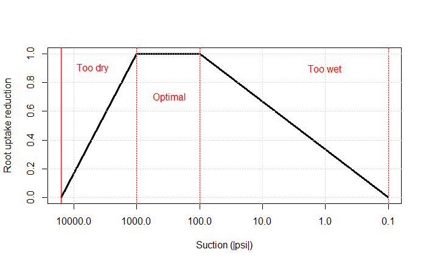

### Adding this spatial flux to the model

The effect of the vegetation, toots extracting water from the soil for transpiration depending on the root distribution, suction ($\psi$) and the potential evapotranpsiration.

Three aspects are considered:

1. Rooting distribution `root.distr.fun`
2. Feddes function `Feddes.fun`
3. Potential evapotranspiration `Epot`

The function to calculate this is : `Eact = root.distr.fun(z)*Feddes.fun(psi)*Epot`

```
Eact = function(z,psi)
{
  return(-root.distr.fun(z) * Feddes.fun(psi) * Epot)
}

add.spatialflux(UnsatStat, rate = Eact, name = "Transpiration")
```

## current model

The current model consists of:

- precipitation applied to the upper boundary as a prescribed flux `ppt`
- potential evapotranspiration `epot` as a flux rate to determine Eact
- actual evapotranspiration `Eact` as a spatial flux (along the roots)
- Cauchy type boundary condition at the lower boundary simulating the effect of a local drainage system

```
plot.roots = function(model)
{
  df = dataframe.externalfluxes(model)
  plot(df$`S{Transpiration}dx`,df$x, type = "o", col = "green", lwd = 2.5,
       main = "Moisture extraction by roots in depth", xlab = "rate (cm/d)", ylab = "depth profile")
  abline(h = drn.level, col = "brown", lwd = 3, lty = "dashed")
  text(mean(df$`S{Transpiration}dx`),drn.level,"drainage level", col = "brown")
  grid()
}

summary(UnsatStat)
```

```
one dimensional flow model
name:  Unsaturated zone, 1D stationary
model has 1 spatial flux, with name
 Transpiration
model has no point fluxes
left BC is of type state-flux
right BC is of type given flux

numerical model of type FElinear1D
number of nodes is  1001
```

```
####testing the model with meteo data
ppt = 0.124
Epot = 0.2
do.initialize(UnsatStat, drn.psi.equi)
solve.steps(UnsatStat,verboselevel = 1)
```

```
[1] "iteration 1 ; RMSM= 0.00235097670076953 ; MAM= 0.0704192948191891"
[1] "iteration 2 ; RMSM= 0.000203694967983107 ; MAM= 0.00563151272903777"
[1] "stopped because of small RMSM= 0.000000592539116361649"
$RMSM
[1] 0.0000005925391

$MAM
[1] 0.00001560699
```

```
plot(UnsatStat,fluxplot = T)
```

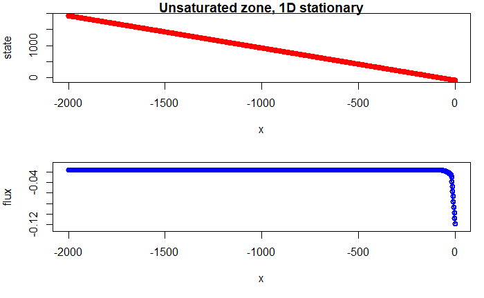

```
plot.wtable(UnsatStat)
```

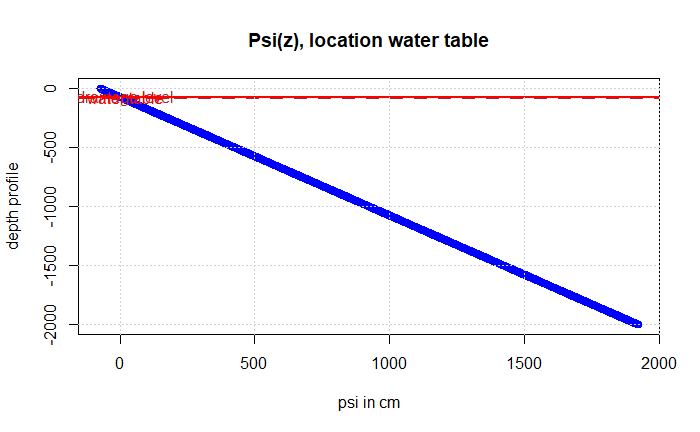

```
plot.theta(UnsatStat)
```

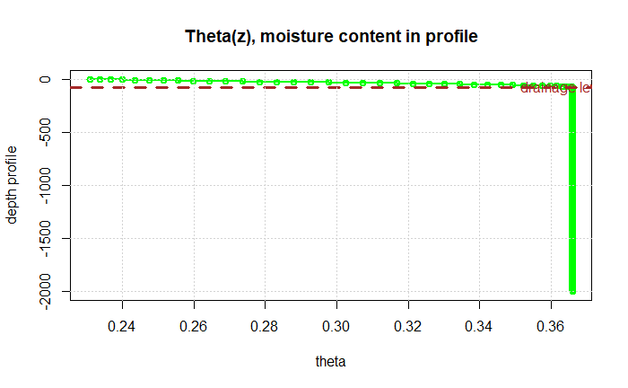

```
plot.roots(UnsatStat)
```

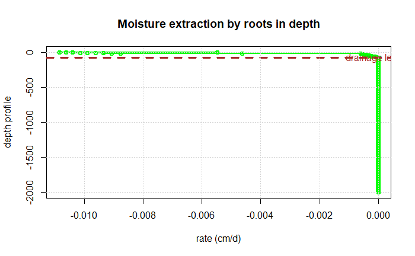

```
bal.asfixedflux = dataframe.balance(UnsatStat)
exter.asfixedflux = dataframe.externalfluxes(UnsatStat)
```

## In case of poding

When the amount of precipitation is larger than the soil can absorb, ponding (nl: plasvorming) will take place To simulate this, an additional Cauchy type boundary condition will be applied to the upper node.

$$q_{ponding} = \frac{\psi_{surface}-0}{C_{top}}$$
It will only be activated when the pressure at the surface (upper node) is larger than 0.0 cm

```
c.top = 5 #days
ponding = function(psi)
{
  if (psi > 0)
  {
    return(-psi/c.top)
  }else{
    return(0)
  }
}
```

## Adjusting the model

We need to replace the `set.BC.fixedflux` upper boundary to an `add.pointflux` function and apply the ponding function to the upper node with `set.BC.fluxstate`.

```
set.BC.fluxstate(model = UnsatStat, where = "right", func = ponding)
add.pointflux(model = UnsatStat, at = 0, value = "ppt", "precipitation")
summary(UnsatStat)
```

```
one dimensional flow model
name:  Unsaturated zone, 1D stationary
model has 1 spatial flux, with name
 Transpiration
model has 1 point flux, with name
 precipitation
left BC is of type state-flux
right BC is of type state-flux

numerical model of type FElinear1D
number of nodes is  1001
```

```
solve.steps(UnsatStat, verboselevel = 1)
```

```
[1] "stopped because of small RMSM= 0.00000000000349867385493809"
$RMSM
[1] 0.000000000003498674

$MAM
[1] 0.00000000008514654
```

```
plot.wtable(UnsatStat)
```

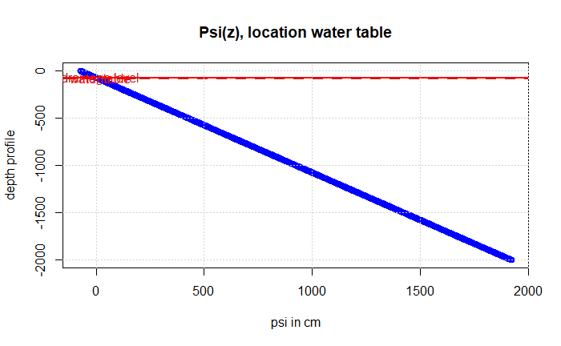

```
plot.theta(UnsatStat)
```

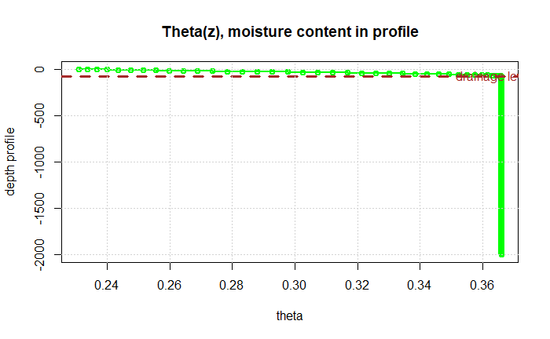

### checking the data from staring reeks

[output not shown]

### setting up the LSA basics

Idea is to see the effect of the derivative of a certain vG parameter w.r.t. a result is large or small.

$\frac{\partial O}{\partial P_i}$

The result is in this case the output of the model:

- water table height
- recharge at the bottom
- actual evapotranspiration (through roots)
- moisture content

Let’s start with recharge at the bottom. So except for one parameter all other parameters and inputs stay the same.

[output not shown]

## The transient model

When the dynamics are introduced into the model times series of different aspects could be analyzed. Introducing dynamics means actually that changes in time are considered. This impacts in the first place the amount of water stored in the model: $\frac{\partial \theta}{\partial t}$.

The basic equation to be solved (Richard’s equation) is:
$$\frac{\partial \theta(\psi)}{\partial t} = -k(\psi)\left [\frac{\partial
\psi}{\partial z} + 1 \right]$$

The moisture (storage) change over time (: $\frac{\partial \theta(\psi)}{\partial t}$) is implemented as a `spatial flux` of time and space Since we are calculating $\psi$ as the state of the model, we are going to use the `theta.fun(psi)` function to determine the amount of moisture content based on the current pressure head ($\psi$)

This can be implemented numerically as:

$$Q_{storage} = \frac{\theta \left (\psi^{t+\Delta t}\right ) - \theta
\left( \psi^t \right ) }{\Delta t}\Delta z$$
The new/current pressure head is the one which is evaluated at the new time step: $\psi^{t+\Delta t}$ but since we also need to consider the previous pressure head $\psi^t$, we will save these pressure just before we start with a new time step and call this `psi.old`.
When more water is stored in the model, it means that less is available for flow. This means that a minus sign should be introduced. This could easily be accomplished by switching both pressure heads in the aforementioned equation.

```
storage = function(z,state)
{
  storage = (theta.fun(psi.old(z)) - theta.fun(state))/delta.t
}
```

Be aware the `storage` function will be multiplied with the nodal distance internally to come to the unit of L/T (cm/d).

### Setting up the transient model

A copy of the stationary model is used to quickly set up the transient model

```
UnsatTrans = copy.model(UnsatStat)
add.spatialflux(UnsatTrans, rate = storage, name = "Storage")
do.initialize(UnsatTrans, init = drn.psi.equi)
psi.old = state.fun(UnsatTrans) #setting the strating state of the transient simulation to determine the first storage change
```

Creating a time loop for the calculations

A function to write the required out put in different data.frames for analysis and inspection later on.

```
save.data = function(model = modelname)
{
  df.state = dataframe.states(model)
  state.tmp <<- rbind(state.tmp,df.state$state) #adding the states (psi) to this data.frame
  df.extern = dataframe.externalfluxes(model)
  transp.tmp <<- rbind(transp.tmp,df.extern$`S{Transpiration}dx`) #for transpiration(roots) data
  moist.tmp <<- rbind(moist.tmp,df.extern$`S{Storage}dx`)
  #balance terms transp:[2,3],flow2sto:[3,2],sto2flow[3,3]
  df.balance = dataframe.balance(model)
  #the drainage/upward seepage at the bottom will be written in balance.dat
  df.bound = dataframe.boundaries(model)
  balance.tmp <<- rbind(balance.tmp,c(precip[current.time],evapot[current.time],
                                      df.balance[2,3],df.balance[3,2],
                                      df.balance[3,3],df.bound[1,4],df.bound[2,4]))
}
```

Reading some meteo data from KNMI, precipitation and potential evapotranspiration In the file it reads: RH = Etmaalsom van de neerslag (in 0.1 mm) (-1 voor <0.05 mm) / Daily precipitation amount (in 0.1 mm) (-1 for <0.05 mm) EV24 = Referentiegewasverdamping (Makkink) (in 0.1 mm) / Potential evapotranspiration (Makkink) (in 0.1 mm)

```
meteo = read.table(file = "ppt_epot2020.txt", header = TRUE)
names(meteo) = c("date","ppt","epot")
#adjusting the unit to cm/day
precip = meteo$ppt/100
evapot = meteo$epot/100
#correcting for the -1 symbol and setting these values to 0
precip[which(precip < 0)] = 0
evapot[which(evapot < 0)] = 0
```

### Base run

```
#This base run is based on a B01 Soil
generate.vG.curves("B01",1.801,0.0234,0.43,0.02,23.41,-0.000)#data of B1

base.n = 1.801
base.alpha = 0.0234
base.thetasat = 0.43
base.thetares = 0.02
base.Ksat = 23.41
base.lambda = -0.000


begin.time  = 1
current.time = begin.time
end.time = length(meteo$date)
delta.t = 1 #day, i.e. the time stepping

#precip = c(0.01,0.02,0.03,0.0,0.4,0.0,0.0,0.15,0.015,0.2)
#evapot = c(0.0,0.03,0.08,0.1,0.125,0.09,0.2,0.25,0.05,0.12)

####containers to save intermediate results
state.tmp = c()
transp.tmp = c()
moist.tmp = c()
balance.tmp = c()

##set the initial state to equilibrium
do.initialize(UnsatTrans, init = drn.psi.equi)
start.run.time = Sys.time()
while(current.time <= end.time)
{
  ppt = precip[as.integer(current.time)]
  Epot = evapot[as.integer(current.time)]
  psi.old = state.fun(UnsatTrans)
  solve.steps(UnsatTrans)#,verboselevel = 1)
  cat(paste("day nr.:",current.time, "\n"))
  save.data(UnsatTrans)
  current.time = current.time + delta.t
  ####plotting some stuff
  # old.par = par(no.readonly=TRUE) #to save current plot settings and stuff
  # layout = matrix(c(2,2),ncol = 2)#, byrow = TRUE)
  # plot.roots(UnsatTrans)
  # plot.theta(UnsatTrans)
  # plot.wtable(UnsatTrans)
  # par = old.par
  #####saving the results
}
```

[output not shown]

[output cut: 310 more lines]

```
day nr.: 351
day nr.: 352
day nr.: 353
day nr.: 354
day nr.: 355
day nr.: 356
day nr.: 357
day nr.: 358
day nr.: 359
day nr.: 360
day nr.: 361
day nr.: 362
day nr.: 363
day nr.: 364
day nr.: 365
```

```
end.run.time = Sys.time()

cat(paste("simulation time is :",end.run.time - start.run.time))
```

```
simulation time is : 15.7440228819847
```

```
## to make dataframes and csv's from the saved data
balance.res = data.frame(balance.tmp)
time.series = seq(begin.time,end.time,by = delta.t) #add this to the balanc.res data.frame for use with IJPlot
balance.res = cbind(time.series,balance.res)
names(balance.res) = c("Daynr","Precip","Epot","Eact","Sto2flow","Flow2sto","Recharge","Ponding")
write.csv(x = balance.res, file = "Balance.csv")
state.res = data.frame(state.tmp)
names(state.res) = as.character(nodes)
write.csv(x = state.res, file = "States.csv")
transp.res = data.frame(transp.tmp)
names(transp.res) = as.character(nodes)
write.csv(x = transp.res, file = "Transp.csv")
moist.res = data.frame(moist.tmp)
names(moist.res) = as.character(nodes)
write.csv(x = moist.res, file = "Moisture.csv")


## creating the base output data.frames
balance.base = balance.res
state.base = state.res
transp.base = transp.res
moist.base = moist.res
```

#### LSA on transient simulations

Calculate the LSA by:

$$VAR(O_i)= \sum \left [ \frac{1}{\epsilon_{P_j}} \left( 1/T\sum^T_{t=1}
\left( O_i(t)^{P_j}-O_i(t)^{P_j+\epsilon_{P_j}}\right ) \right ) \sigma
P_j \right ]^2$$
So $O_i$ is for example the recharge and $P_j$ is $\alpha$. The term between the large parenthesis (curved brackets) is in this case simply the time average of $O_i(t)^{P_j}-O_i(t)^{P_j+\epsilon_{P_j}}$ in this example the recharge and this can be easily calculated by calculating the mean difference between `balance.base$recharge - balance.res$recharge`

We will take a relative fraction (1%) of the parameter value being the $\epsilon$. Sometimes the $\lambda$ value seems to have a value of 0.000 or even -0.000. In this case a fixed of for example $\epsilon_\lambda = 0.001$ could be used.

```
##LSA on kSat parameter
ksat.eps = 0.01 * base.Ksat #calculate the epsilon
#generate new curves based on Ksat + ksat.eps
generate.vG.curves("B01",base.n,base.alpha,base.thetasat,base.thetares,base.Ksat+ksat.eps, base.lambda)
##
##Run the transient model with these parameters
## this chunck is the same as before
begin.time  = 1
current.time = begin.time
end.time = length(meteo$date)
delta.t = 1 #day, i.e. the time stepping

####containers to save intermediate results
state.tmp = c()
transp.tmp = c()
moist.tmp = c()
balance.tmp = c()

#set the initial state (psi) distribution
do.initialize(UnsatTrans, init = drn.psi.equi)

while(current.time <= end.time)
{
  ppt = precip[as.integer(current.time)]
  Epot = evapot[as.integer(current.time)]
  psi.old = state.fun(UnsatTrans)
  solve.steps(UnsatTrans)#,verboselevel = 1)
  cat(paste("day nr.:",current.time, "\n"))
  save.data(UnsatTrans)
  current.time = current.time + delta.t
}

## to make dataframes and csv's from the saved data
balance.res = data.frame(balance.tmp)
time.series = seq(begin.time,end.time,by = delta.t) #add this to the balanc.res data.frame for use with IJPlot
balance.res = cbind(time.series,balance.res)
names(balance.res) = c("Daynr","Precip","Epot","Eact","Sto2flow","Flow2sto","Recharge","Ponding")
write.csv(x = balance.res, file = "Balance.csv")
state.res = data.frame(state.tmp)
names(state.res) = as.character(nodes)
```

[output cut: 21 more lines]

```
wtable.fun = function(x)
{
  psi.fun = approxfun(x,nodes)
  return(psi.fun(0))
}
wtable.base = apply(X=state.base, MARGIN = 1, FUN = function(x){wtable.fun(x)})
wtable.res = apply(X=state.res,MARGIN = 1, FUN = function(x){wtable.fun(x)})

dwtable.dKsat.mean = mean((wtable.base - wtable.res),na.rm = TRUE)/ksat.eps
dwtable.dKsat.absmean = mean(abs(wtable.base - wtable.res),na.rm = TRUE)/ksat.eps
dwtable.dKsat.sumvar = sum((wtable.base - wtable.res)^2, na.rm = TRUE)/ksat.eps
dwtable.dKsat.VAR = 1/length(balance.base$Recharge) * sum((wtable.base - wtable.res)^2, na.rm = TRUE)/ksat.eps

###reset the van Genuchten parameters
generate.vG.curves("B01",base.n,base.alpha,base.thetasat,base.thetares,base.Ksat, base.lambda)
```

### Viewing the results

```
plot.trans.balance = function() # this is a very basic simple and generic R plot
{
  time.series = c(1:length(balance.res[,1]))
  flux.range = range(balance.res[,2:8])
  plot(x = time.series , y = balance.res$Eact, ylim = flux.range, xlab = "time (d)",
       ylab = "flux rate cm/d", main = "Water balance terms", type = "l",
       lwd = 2, col = "red")
  lines(x = time.series, y = balance.res$Sto2flow, lwd = 2,col = "lightblue")
  lines(x = time.series, y = balance.res$Flow2sto, lwd = 2, col = "lightgreen")
  lines(x = time.series, y = balance.res$Recharge, lwd = 2, col = "magenta")
  lines(x = time.series, y = balance.res$Precip, lwd = 2, col = 'blue')
  lines(x = time.series, y = balance.res$Ponding, lwd = 2, col = 'orange')
  lines(x = time.series, y = balance.res$Epot, lwd = 2, col = 'tomato3')
  grid()
}
plot.trans.balance() # this a very basic simple and generic R plot
```

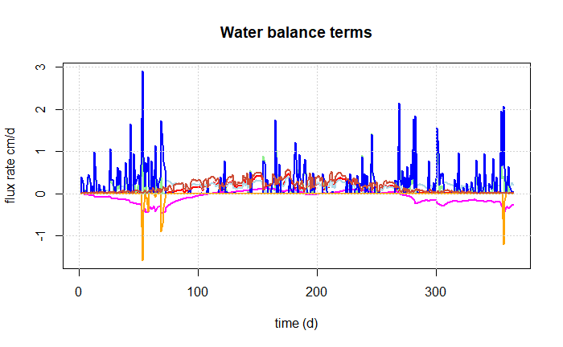

```
#below the IJPLOT package is used to plot different type of data

balance.plot = new_miplot(name = "balance",fxright = 0.90, rightmargin = 0.0)
color.set = rainbow(n = length(balance.res[1,]))
add_line(balance.plot, data = balance.res,dataxname = names(balance.res[1]), datayname = names(balance.res[2]), color = color.set[2],width = 2)
add_line(balance.plot, data = balance.res,dataxname = names(balance.res[1]), datayname = names(balance.res[3]), color = color.set[3],width = 2)
add_line(balance.plot, data = balance.res,dataxname = names(balance.res[1]),datayname = names(balance.res[4]), color = color.set[4],width = 2)
add_line(balance.plot, data = balance.res,dataxname = names(balance.res[1]),datayname = names(balance.res[5]), color = color.set[5],width = 2)
add_line(balance.plot, data = balance.res,dataxname = names(balance.res[1]),datayname = names(balance.res[6]), color = color.set[6],width = 2)
add_line(balance.plot, data = balance.res,dataxname = names(balance.res[1]),datayname = names(balance.res[7]), color = color.set[7],width = 2)
add_line(balance.plot, data = balance.res,dataxname = names(balance.res[1]),datayname = names(balance.res[8]), color = color.set[8],width = 2)
add_xlabel(balance.plot, text = "time steps (d)", fontsize = 12)
add_ylabel(balance.plot, text = "flux rate (cm/d)", fontsize = 12, offset = 25)
add_title(balance.plot, text = "Water balance terms")
add_vline(balance.plot, x = seq(min(balance.res[,1]),max(balance.res[,1]),length.out = 5), dash=c(2,2), color = "grey")
add_hline(balance.plot, y = seq(min(balance.res[,2:8]),max(balance.res[,2:8]),length.out = 5),dash=c(2,2), color = "grey")

legend.plot = new_miplot(name = "legend",yfixed = TRUE, xfixed = TRUE,fxleft = 0.90,fybottom = 0.7,
                         bottommargin = 0, leftmargin = 0, horaxisnumdiv = 0, veraxisnumdiv = 0,
                         imposedmaxx= max(nchar(names(balance.res))))

for (i in 2:length(balance.res[1,]))
{
  add_points(mip = legend.plot,x = 0, y = length(balance.res[1,])-i, marker = "square",size = 8, fillcolor = color.set[i])
  add_text(mip = legend.plot, atx= 0, aty = length(balance.res[1,])-i,text = paste(names(balance.res[i])),fontsize = 12,
           pos = "E",offset = 5)
}

###for testing
write.table(moist.res,file = "moisture.dat")
write.table(transp.res, file = "transp.dat")

###
draw(balance.plot,legend.plot)
```

[interactive chart not shown]

```
flux.plot = new_ijplot(name = "flux", fxright = 0.90, rightmargin = 0.0)
```

[output not shown]